# A Homework of Biblical Proportions

Yuhao Wang & Meiyuan Li

In this HW, we will analyze the text of the bible. The ascii version resides in the file “ascii_bible.txt” on Camino. Use an editor to familiarize yourself with the structure of the file. Then perform the following operations, listed below as questions for you to answer.

## Q1: Read in the file using any R function you like and store each verse in a text array. After which print the top 20 verses. (Remove the top two lines which contain the title.)

```r
library(stringr)
text <- readLines("/Users/yuhaowang/Downloads/ascii_bible.txt")
text <- str_replace(text,"^\\s+","")
verses_len <- grep("[0-9][0-9][0-9]:[0-9][0-9][0-9]",text)
helper <- NULL
for (i in seq(1:(length(verses_len)-1))){
  temp <- paste(text[verses_len[i]:(verses_len[i+1]-1)],collapse = " ")
  helper <- c(helper,temp)
}
verses <- c(helper,paste(text[verses_len[length(verses_len)]:length(text)],collapse = " "))
verses[1:20]
```

```
##  [1] "001:001 In the beginning God created the heaven and the earth. "
##  [2] "001:002 And the earth was without form, and void; and darkness was upon the face of the deep. And the Spirit of God moved upon the face of the waters. "
##  [3] "001:003 And God said, Let there be light: and there was light. "
##  [4] "001:004 And God saw the light, that it was good: and God divided the light from the darkness. "
##  [5] "001:005 And God called the light Day, and the darkness he called Night. And the evening and the morning were the first day. "
##  [6] "001:006 And God said, Let there be a firmament in the midst of the waters, and let it divide the waters from the waters. "
##  [7] "001:007 And God made the firmament, and divided the waters which were under the firmament from the waters which were above the firmament: and it was so. "
##  [8] "001:008 And God called the firmament Heaven. And the evening and the morning were the second day. "
##  [9] "001:009 And God said, Let the waters under the heaven be gathered together unto one place, and let the dry land appear: and it was so. "
## [10] "001:010 And God called the dry land Earth; and the gathering together of the waters called he Seas: and God saw that it was good. "
## [11] "001:011 And God said, Let the earth bring forth grass, the herb yielding seed, and the fruit tree yielding fruit after his kind, whose seed is in itself, upon the earth: and it was so. "
## [12] "001:012 And the earth brought forth grass, and herb yielding seed after his kind, and the tree yielding fruit, whose seed was in itself, after his kind: and God saw that it was good. "
## [13] "001:013 And the evening and the morning were the third day. "
## [14] "001:014 And God said, Let there be lights in the firmament of the heaven to divide the day from the night; and let them be for signs, and for seasons, and for days, and years: "
## [15] "001:015 And let them be for lights in the firmament of the heaven to give light upon the earth: and it was so. "
## [16] "001:016 And God made two great lights; the greater light to rule the day, and the lesser light to rule the night: he made the stars also. "
## [17] "001:017 And God set them in the firmament of the heaven to give light upon the earth, "
## [18] "001:018 And to rule over the day and over the night, and to divide the light from the darkness: and God saw that it was good. "
## [19] "001:019 And the evening and the morning were the fourth day. "
## [20] "001:020 And God said, Let the waters bring forth abundantly the moving creature that hath life, and fowl that may fly above the earth in the open firmament of heaven. "
```

## Q2: How many verses are there in total?

```r
length(verses)
```

```
## [1] 31102
```

## Q3: Each verse has the number “CCC:VVV” where CCC is the chapter number and VVV is the verse number. How many chapters are there?

```r
chapter <- grep("[0-9][0-9][0-9]:001", verses)
length(chapter)
```

```
## [1] 1189
```

## Q4: Extract an array for the verse numbers, and also one for the verse text.

```r
verses_no <- c(substr(verses,5,7))
verses_text <-  str_split_fixed(verses, "[0-9][0-9][0-9]:[0-9][0-9][0-9] ",2)
verses_text <- verses_text[,2]
head(verses_no)
```

```
## [1] "001" "002" "003" "004" "005" "006"
```

```r
head(verses_text)
```

```
## [1] "In the beginning God created the heaven and the earth. "
## [2] "And the earth was without form, and void; and darkness was upon the face of the deep. And the Spirit of God moved upon the face of the waters. "
## [3] "And God said, Let there be light: and there was light. "
## [4] "And God saw the light, that it was good: and God divided the light from the darkness. "
## [5] "And God called the light Day, and the darkness he called Night. And the evening and the morning were the first day. "
## [6] "And God said, Let there be a firmament in the midst of the waters, and let it divide the waters from the waters. "
```

## Q5: Lower case all text.

```r
verses_text <- str_to_lower(verses_text)
head(verses_text)
```

```
## [1] "in the beginning god created the heaven and the earth. "
## [2] "and the earth was without form, and void; and darkness was upon the face of the deep. and the spirit of god moved upon the face of the waters. "
## [3] "and god said, let there be light: and there was light. "
## [4] "and god saw the light, that it was good: and god divided the light from the darkness. "
## [5] "and god called the light day, and the darkness he called night. and the evening and the morning were the first day. "
## [6] "and god said, let there be a firmament in the midst of the waters, and let it divide the waters from the waters. "
```

## Q6: Convert the text of all verses into a Corpus using the **tm** package.

```r
library(NLP)
library(tm)
verses_text <- Corpus(VectorSource(verses_text))
verses_text
```

```
## <<SimpleCorpus>>
## Metadata:  corpus specific: 1, document level (indexed): 0
## Content:  documents: 31102
```

## Q7: Remove all punctuation. Use a corpus function for this. How many unique words are there in the bible?

```r
verses_text <- tm_map(verses_text, removePunctuation)
verses_unique <- DocumentTermMatrix(verses_text)
verses_unique
```

```
## <<DocumentTermMatrix (documents: 31102, terms: 12651)>>
## Non-/sparse entries: 510124/392961278
## Sparsity           : 100%
## Maximal term length: 18
## Weighting          : term frequency (tf)
```

```r
#12651 unique words
```

## Q8: Remove all stopwords. Now how many unique terms are there?

```r
verses_stop <- verses_text
verses_stop <- tm_map(verses_stop, removeWords, stopwords("english"))
verses_stop_uniq <- DocumentTermMatrix(verses_stop)
verses_stop_uniq
```

```
## <<DocumentTermMatrix (documents: 31102, terms: 12555)>>
## Non-/sparse entries: 336052/390149558
## Sparsity           : 100%
## Maximal term length: 18
## Weighting          : term frequency (tf)
```

```r
#12555 unique terms
```

## Q9: Now stem the text, to remove multiplicity of similar words of the same root.

```r
verses_stem <- tm_map(verses_stop, stemDocument)
verses_stem
```

```
## <<SimpleCorpus>>
## Metadata:  corpus specific: 1, document level (indexed): 0
## Content:  documents: 31102
```

## Q10: How many distinct words are there in the bible, after stemming?

```r
verses_stem_unique <- DocumentTermMatrix(verses_stem)
verses_stem_unique
```

```
## <<DocumentTermMatrix (documents: 31102, terms: 9125)>>
## Non-/sparse entries: 332862/283472888
## Sparsity           : 100%
## Maximal term length: 18
## Weighting          : term frequency (tf)
```

```r
#9125 distinct words
```

## Q11: Convert the TDM into a matrix and find the 50 most common words in the bible.

```r
verses_rmv_spr <- removeSparseTerms(verses_stem_unique, 0.99)
verses_m <- as.matrix(verses_rmv_spr)
wordcount <- sort(colSums(verses_m), decreasing = TRUE)
head(wordcount, 50)
```

```
##    shall     unto     lord     thou      god      thi     said     will
##     9838     8997     8007     5474     4727     4600     3999     3893
##     thee      son     king     upon      man      day   israel      say
##     3826     3486     2877     2748     2735     2611     2575     2532
##     hath     hous    peopl     came     come      one     hand children
##     2264     2160     2145     2093     2088     2046     1943     1821
##     also     land    thing      men   father    shalt      let     even
##     1769     1767     1704     1677     1675     1616     1512     1454
##     made     went    offer      now   behold     citi    saith     word
##     1405     1400     1368     1356     1341     1316     1262     1245
## therefor    everi     hast     name     make    great    david      may
##     1237     1236     1150     1135     1086     1081     1064     1027
##     pass    earth
##     1004      992
```

## Q12: Make a wordcloud of the top 100 words in the bible.

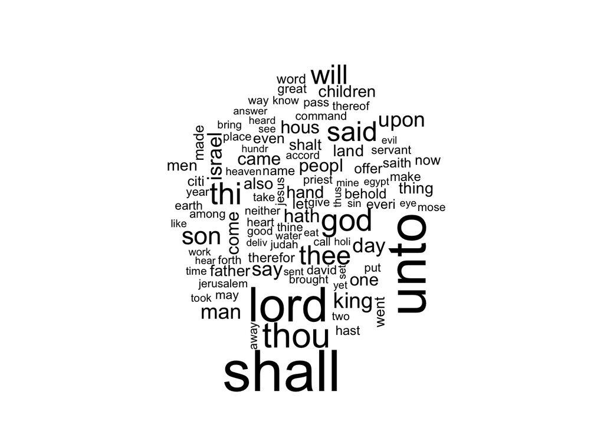

```r
library(wordcloud)
wordcloud(names(head(wordcount, 100)), head(wordcount, 100))
```

## Q13: Mood score the original text of the bible (before stemming)

```r
HIDict <- readLines("/Users/yuhaowang/Downloads/inqdict.txt")
dict_pos <- HIDict[grep("Pos",HIDict)]
poswords <- NULL
for (s in dict_pos) {
    s <- strsplit(s,"#")[[1]][1]
    poswords <- c(poswords,strsplit(s," ")[[1]][1])
}
dict_neg <- HIDict[grep("Neg",HIDict)]
negwords <- NULL
for (s in dict_neg) {
    s <- strsplit(s,"#")[[1]][1]
    negwords <- c(negwords,strsplit(s," ")[[1]][1])
}
poswords <- tolower(poswords)
negwords <- tolower(negwords)
poswords <- unique(poswords)
negwords <- unique(negwords)


verses_mood <-  str_split_fixed(verses, "[0-9][0-9][0-9]:[0-9][0-9][0-9] ",2)
verses_mood <- verses_mood[,2]
verses_mood <- Corpus(VectorSource(verses_mood))
verses_mood <- tm_map(verses_mood,removePunctuation)
verses_mood <- data.frame(text = sapply(verses_mood, as.character), stringsAsFactors = FALSE)
verses_mood <- str_replace(verses_mood$text,"^\\s+","")
verses_mood <- trimws(verses_mood,which = "right")
verses_mood <- str_to_lower(verses_mood)
verses_mood1 <- unlist(strsplit(verses_mood," "))
posmatch <- match(verses_mood1,poswords)
posmatch_no <- length(posmatch[which(posmatch>0)])
negmatch <- match(verses_mood1,negwords)
negmatch_no <- length(negmatch[which(negmatch>0)])
print(c(posmatch_no,negmatch_no))
```

```
## [1] 56827 38769
```

## Q14: Summarize the bible into less than 500 verses. (Or some fraction of the total number of verses, it’s your choice.) Be super careful here as this may take a long time unless you are clever about it, or find some elegant way to speed things up!

```r
text_summary <- function(text, n) {
  m <- length(text)  # No of sentences in input
  jaccard <- matrix(0,m,m)  #Store match index
  for (i in 1:m) {
    for (j in i:m) {
      a <- text[i]; aa <- unlist(strsplit(a," "))
      b <- text[j]; bb <- unlist(strsplit(b," "))
      jaccard[i,j] <- length(intersect(aa,bb))/
                          length(union(aa,bb))
      jaccard[j,i] <- jaccard[i,j]
    }
  }
  similarity_score <- rowSums(jaccard)
  res <- sort(similarity_score, index.return=TRUE,
          decreasing=TRUE)
  idx <- res$ix[1:n]
  summary <- text[idx]
}

a <- c(2,2)
b <- c(2,2)
temp <- data.frame(a,b)
column_names <- c("Verse")
temp = `colnames<-`(temp,column_names)
count <- 1
for(verse in verses_mood){
  ver <- unlist(strsplit(verse," "))
  posmatch <- match(ver,poswords)
  numposmatch <- length(posmatch[which(posmatch>0)])
  negmatch <- match(ver,negwords)
  numnegmatch = length(negmatch[which(negmatch>0)])
  if(numposmatch > 5 | numnegmatch > 5){
    temp[count,1] <- verse
    count <- count + 1
  }
}

summary <- text_summary(temp$Verse, 500)
print(summary)
```

```
##   [1] "for this is the covenant that i will make with the house of israel after those days saith the lord i will put my laws into their mind and write them in their hearts and i will be to them a god and they shall be to me a people"
##   [2] "and i will give them an heart to know me that i am the lord and they shall be my people and i will be their god for they shall return unto me with their whole heart"
##   [3] "and their nobles shall be of themselves and their governor shall proceed from the midst of them and i will cause him to draw near and he shall approach unto me for who is this that engaged his heart to approach unto me saith the lord"
##   [4] "your kerchiefs also will i tear and deliver my people out of your hand and they shall be no more in your hand to be hunted and ye shall know that i am the lord"
##   [5] "and i will sow her unto me in the earth and i will have mercy upon her that had not obtained mercy and i will say to them which were not my people thou art my people and they shall say thou art my god"
##   [6] "and he saith unto them ye shall drink indeed of my cup and be baptized with the baptism that i am baptized with but to sit on my right hand and on my left is not mine to give but it shall be given to them for whom it is prepared of my father"
##   [7] "and it shall come to pass while my glory passeth by that i will put thee in a clift of the rock and will cover thee with my hand while i pass by"
##   [8] "be not afraid of the king of babylon of whom ye are afraid be not afraid of him saith the lord for i am with you to save you and to deliver you from his hand"
##   [9] "be strong and of a good courage fear not nor be afraid of them for the lord thy god he it is that doth go with thee he will not fail thee nor forsake thee"
##  [10] "now therefore call unto me all the prophets of baal all his servants and all his priests let none be wanting for i have a great sacrifice to do to baal whosoever shall be wanting he shall not live but jehu did it in subtilty to the intent that he might destroy the worshippers of baal"
##  [11] "and it shall come to pass in that day that a great tumult from the lord shall be among them and they shall lay hold every one on the hand of his neighbour and his hand shall rise up against the hand of his neighbour"
##  [12] "and the lord said unto moses go in unto pharaoh for i have hardened his heart and the heart of his servants that i might shew these my signs before him"
##  [13] "but i say unto you that whosoever is angry with his brother without a cause shall be in danger of the judgment and whosoever shall say to his brother raca shall be in danger of the council but whosoever shall say thou fool shall be in danger of hell fire"
##  [14] "but this shall be the covenant that i will make with the house of israel after those days saith the lord i will put my law in their inward parts and write it in their hearts and will be their god and they shall be my people"
##  [15] "i have raised him up in righteousness and i will direct all his ways he shall build my city and he shall let go my captives not for price nor reward saith the lord of hosts"
```

[output cut: 485 more lines]

## Q15: Find the main 3 topics in the bible, and the top 25 words in each topic. Can you find an interpretation of each topic?

```r
library(topicmodels)
verses_m <- verses_m[apply(verses_m[,-1], 1, function(x) !all(x==0)),]
lda <- LDA(verses_m, k=3)
(term <- terms(lda, 25))
```

```
##       Topic 1  Topic 2    Topic 3
##  [1,] "shall"  "lord"     "shall"
##  [2,] "unto"   "thi"      "god"
##  [3,] "peopl"  "thou"     "unto"
##  [4,] "thi"    "will"     "said"
##  [5,] "thing"  "unto"     "thou"
##  [6,] "hath"   "children" "day"
##  [7,] "said"   "upon"     "thee"
##  [8,] "thou"   "son"      "will"
##  [9,] "israel" "shall"    "man"
## [10,] "king"   "thee"     "king"
## [11,] "hand"   "come"     "son"
## [12,] "also"   "citi"     "offer"
## [13,] "say"    "israel"   "one"
## [14,] "one"    "came"     "behold"
## [15,] "upon"   "hous"     "come"
## [16,] "thee"   "land"     "came"
## [17,] "shalt"  "brought"  "say"
## [18,] "men"    "hath"     "hand"
## [19,] "son"    "two"      "pass"
## [20,] "god"    "say"      "earth"
## [21,] "man"    "hast"     "let"
## [22,] "even"   "priest"   "jerusalem"
## [23,] "hous"   "word"     "father"
## [24,] "father" "name"     "went"
## [25,] "work"   "great"    "thereof"
```